# Results for Constrained GMM Estimator

Frank DiTraglia

March 18, 2017

The true value of $\alpha_1$ in this simulation was 0.1. I tried three different values for $\beta$: 0.5, 0.3, and 0.1. All other parameters were fixed at the defaults we’ve been using thus far, namely $n = 1000$, $\delta = 0.15$ and $\rho = 0.5$. Results are based on 1000 simulation replications

```r
load('~/binary-regressor/mbereg_test.Rd')
sim_b_equals_0_point_5 <- sim_results$`b=0.5`
sim_b_equals_0_point_3 <- sim_results$`b=0.3`
sim_b_equals_0_point_1 <- sim_results$`b=0.1`
```

## First Experiment: $\beta = 0.5$

### Results for $\alpha_1$

The sampling distribution of the constrained estimator for $\alpha_1$ is highly non-normal:

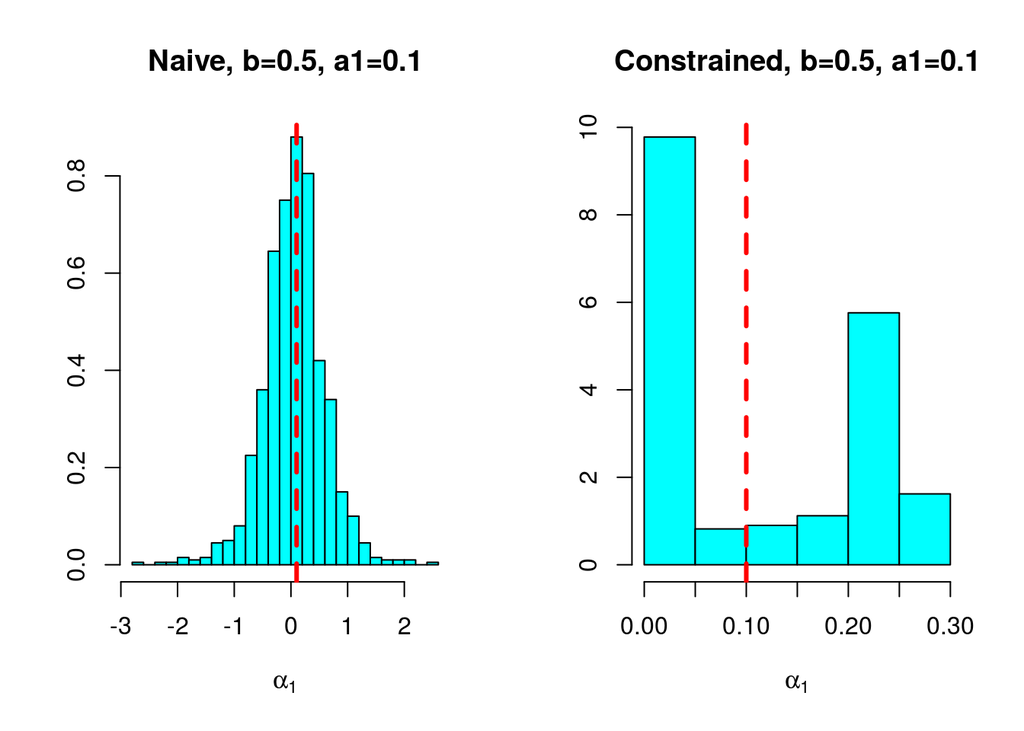

```r
par(mfrow = c(1, 2))
MASS::truehist(sim_b_equals_0_point_5$a1_naive,
               xlab = expression(alpha[1]),
               main = "Naive, b=0.5, a1=0.1")
abline(v = 0.1, lwd = 3, lty = 2, col = 'red')
MASS::truehist(sim_b_equals_0_point_5$a1_constr,
               xlab = expression(alpha[1]),
               main = "Constrained, b=0.5, a1=0.1")
abline(v = 0.1, lwd = 3, lty = 2, col = 'red')
```

```r
par(mfrow = c(1, 1))
```

but the constrained estimator is much less variable:

```r
c(naive = sd(sim_b_equals_0_point_5$a1_naive),
  constr = sd(sim_b_equals_0_point_5$a1_constr))
```

```
##     naive    constr
## 0.5444549 0.1097134
```

and approximately unbiased:

```r
c(naive = mean(sim_b_equals_0_point_5$a1_naive) - 0.1,
  constr = mean(sim_b_equals_0_point_5$a1_constr) - 0.1)
```

```
##        naive       constr
## -0.045841046  0.006851072
```

### Results for $\beta$

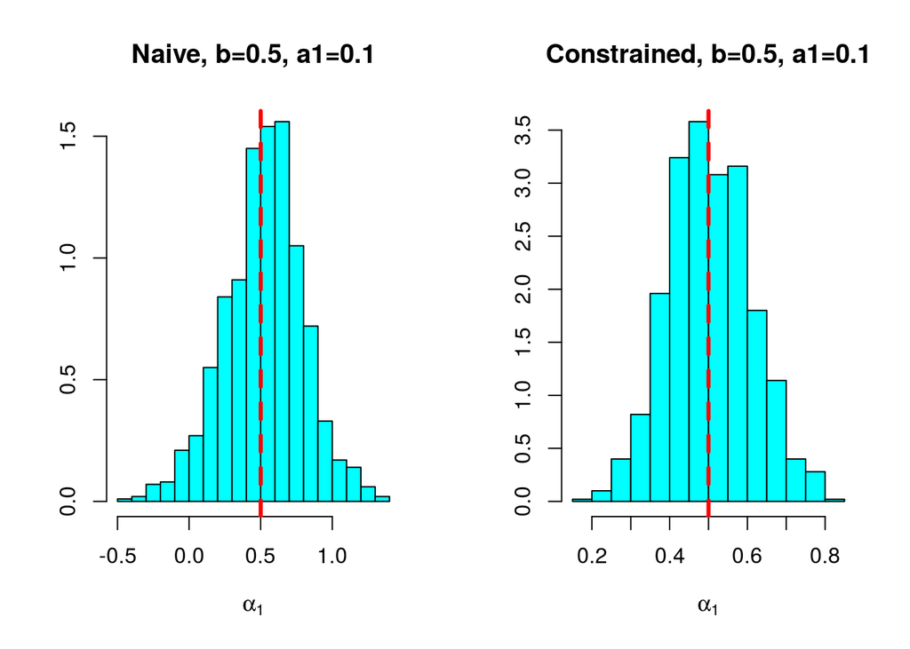

```r
par(mfrow = c(1, 2))
MASS::truehist(sim_b_equals_0_point_5$b_naive,
               xlab = expression(alpha[1]),
               main = "Naive, b=0.5, a1=0.1")
abline(v = 0.5, lwd = 3, lty = 2, col = 'red')
MASS::truehist(sim_b_equals_0_point_5$b_constr,
               xlab = expression(alpha[1]),
               main = "Constrained, b=0.5, a1=0.1")
abline(v = 0.5, lwd = 3, lty = 2, col = 'red')
```

```r
par(mfrow = c(1, 1))
```

Again, the constrained estimator is much less variable:

```r
c(naive = sd(sim_b_equals_0_point_5$b_naive),
  constr = sd(sim_b_equals_0_point_5$b_constr))
```

```
##     naive    constr
## 0.2764118 0.1064957
```

and also shows a smaller bias:

```r
c(naive = mean(sim_b_equals_0_point_5$b_naive) - 0.5,
  constr = mean(sim_b_equals_0_point_5$b_constr) - 0.5)
```

```
##       naive      constr
## 0.023075428 0.003693734
```

## Second Experiment: $\beta = 0.3$

### Results for $\alpha_1$

The sampling distribution of the constrained estimator for $\alpha_1$ is highly non-normal:

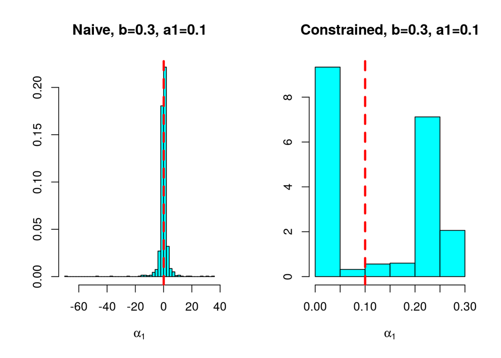

```r
par(mfrow = c(1, 2))
MASS::truehist(sim_b_equals_0_point_3$a1_naive,
               xlab = expression(alpha[1]),
               main = "Naive, b=0.3, a1=0.1")
abline(v = 0.1, lwd = 3, lty = 2, col = 'red')
MASS::truehist(sim_b_equals_0_point_3$a1_constr,
               xlab = expression(alpha[1]),
               main = "Constrained, b=0.3, a1=0.1")
abline(v = 0.1, lwd = 3, lty = 2, col = 'red')
```

```r
par(mfrow = c(1, 1))
```

but the constrained estimator is much less variable:

```r
c(naive = sd(sim_b_equals_0_point_3$a1_naive),
  constr = sd(sim_b_equals_0_point_3$a1_constr))
```

```
##     naive    constr
## 4.3279046 0.1145554
```

and approximately unbiased:

```r
c(naive = mean(sim_b_equals_0_point_3$a1_naive) - 0.1,
  constr = mean(sim_b_equals_0_point_3$a1_constr) - 0.1)
```

```
##       naive      constr
## -0.13808508  0.01851762
```

### Results for $\beta$

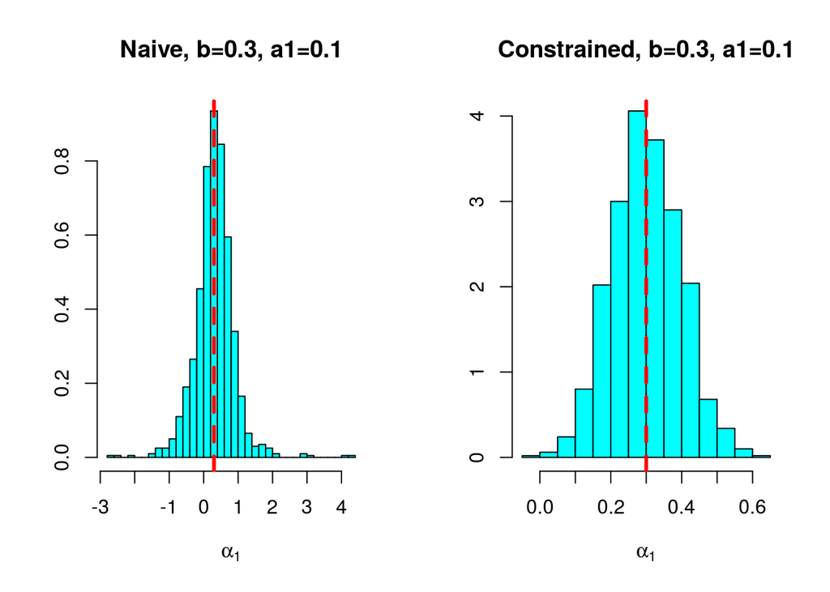

```r
par(mfrow = c(1, 2))
MASS::truehist(sim_b_equals_0_point_3$b_naive,
               xlab = expression(alpha[1]),
               main = "Naive, b=0.3, a1=0.1")
abline(v = 0.3, lwd = 3, lty = 2, col = 'red')
MASS::truehist(sim_b_equals_0_point_3$b_constr,
               xlab = expression(alpha[1]),
               main = "Constrained, b=0.3, a1=0.1")
abline(v = 0.3, lwd = 3, lty = 2, col = 'red')
```

```r
par(mfrow = c(1, 1))
```

Again, the constrained estimator is much less variable:

```r
c(naive = sd(sim_b_equals_0_point_3$b_naive),
  constr = sd(sim_b_equals_0_point_3$b_constr))
```

```
##     naive    constr
## 0.5737274 0.0974630
```

and also shows a smaller bias:

```r
c(naive = mean(sim_b_equals_0_point_3$b_naive) - 0.3,
  constr = mean(sim_b_equals_0_point_3$b_constr) - 0.3)
```

```
##         naive        constr
##  0.0163508053 -0.0000126644
```

## Third Experiment: $\beta = 0.1$

### Results for $\alpha_1$

The sampling distribution of the constrained estimator for $\alpha_1$ is highly non-normal:

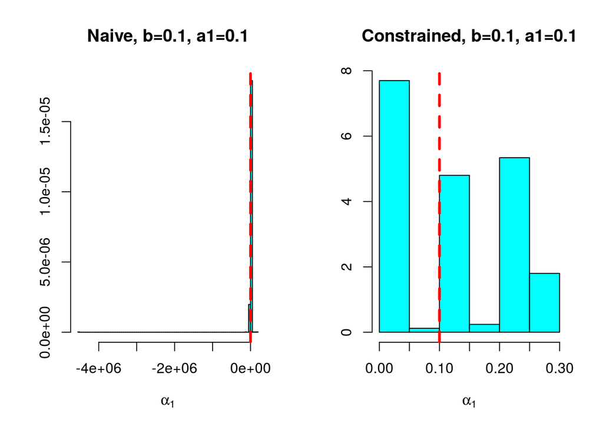

```r
par(mfrow = c(1, 2))
MASS::truehist(sim_b_equals_0_point_1$a1_naive,
               xlab = expression(alpha[1]),
               main = "Naive, b=0.1, a1=0.1")
abline(v = 0.1, lwd = 3, lty = 2, col = 'red')
MASS::truehist(sim_b_equals_0_point_1$a1_constr,
               xlab = expression(alpha[1]),
               main = "Constrained, b=0.1, a1=0.1")
abline(v = 0.1, lwd = 3, lty = 2, col = 'red')
```

```r
par(mfrow = c(1, 1))
```

but the constrained estimator is much less variable:

```r
c(naive = sd(sim_b_equals_0_point_1$a1_naive),
  constr = sd(sim_b_equals_0_point_1$a1_constr))
```

```
##        naive       constr
## 1.439088e+05 1.031597e-01
```

and approximately unbiased:

```r
c(naive = mean(sim_b_equals_0_point_1$a1_naive) - 0.1,
  constr = mean(sim_b_equals_0_point_1$a1_constr) - 0.1)
```

```
##         naive        constr
## -4.338055e+03  1.656017e-02
```

### Results for $\beta$

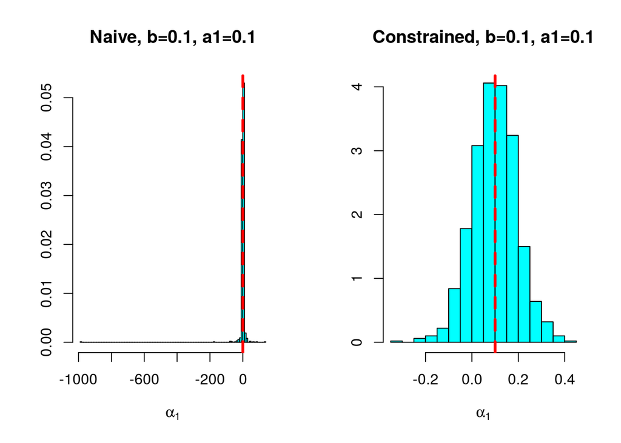

```r
par(mfrow = c(1, 2))
MASS::truehist(sim_b_equals_0_point_1$b_naive,
               xlab = expression(alpha[1]),
               main = "Naive, b=0.1, a1=0.1")
abline(v = 0.1, lwd = 3, lty = 2, col = 'red')
MASS::truehist(sim_b_equals_0_point_1$b_constr,
               xlab = expression(alpha[1]),
               main = "Constrained, b=0.1, a1=0.1")
abline(v = 0.1, lwd = 3, lty = 2, col = 'red')
```

```r
par(mfrow = c(1, 1))
```

Again, the constrained estimator is much less variable:

```r
c(naive = sd(sim_b_equals_0_point_1$b_naive),
  constr = sd(sim_b_equals_0_point_1$b_constr))
```

```
##       naive      constr
## 32.74897789  0.09689389
```

and also shows a smaller bias:

```r
c(naive = mean(sim_b_equals_0_point_1$b_naive) - 0.1,
  constr = mean(sim_b_equals_0_point_1$b_constr) - 0.1)
```

```
##        naive       constr
## -0.917717638 -0.003440695
```